# Swiss Banknote Data

Cheng-Han Shih

2023-04-12

```r
library(MixGHD)
library(APLM)
library(corrplot)
library(ggplot2)
library(GGally)
library(DT)
```

# Data

## Overview

```r
data(banknote)
datatable(banknote)
```

|  | Status | Length | Left | Right | Bottom | Top | Diagonal |
| --- | --- | --- | --- | --- | --- | --- | --- |
| 1 | genuine | 214.8 | 131 | 131.1 | 9 | 9.7 | 141 |
| 2 | genuine | 214.6 | 129.7 | 129.7 | 8.1 | 9.5 | 141.7 |
| 3 | genuine | 214.8 | 129.7 | 129.7 | 8.7 | 9.6 | 142.2 |
| 4 | genuine | 214.8 | 129.7 | 129.6 | 7.5 | 10.4 | 142 |
| 5 | genuine | 215 | 129.6 | 129.7 | 10.4 | 7.7 | 141.8 |
| 6 | genuine | 215.7 | 130.8 | 130.5 | 9 | 10.1 | 141.4 |
| 7 | genuine | 215.5 | 129.5 | 129.7 | 7.9 | 9.6 | 141.6 |
| 8 | genuine | 214.5 | 129.6 | 129.2 | 7.2 | 10.7 | 141.7 |
| 9 | genuine | 214.9 | 129.4 | 129.7 | 8.2 | 11 | 141.9 |
| 10 | genuine | 215.2 | 130.4 | 130.3 | 9.2 | 10 | 140.7 |

[output cut: 190 more lines]

## Summary

```r
str(banknote)
```

```
## 'data.frame':    200 obs. of  7 variables:
##  $ Status  : Factor w/ 2 levels "counterfeit",..: 2 2 2 2 2 2 2 2 2 2 ...
##  $ Length  : num  215 215 215 215 215 ...
##  $ Left    : num  131 130 130 130 130 ...
##  $ Right   : num  131 130 130 130 130 ...
##  $ Bottom  : num  9 8.1 8.7 7.5 10.4 9 7.9 7.2 8.2 9.2 ...
##  $ Top     : num  9.7 9.5 9.6 10.4 7.7 10.1 9.6 10.7 11 10 ...
##  $ Diagonal: num  141 142 142 142 142 ...
```

```r
summary(banknote)
```

```
##          Status        Length           Left           Right
##  counterfeit:100   Min.   :213.8   Min.   :129.0   Min.   :129.0
##  genuine    :100   1st Qu.:214.6   1st Qu.:129.9   1st Qu.:129.7
##                    Median :214.9   Median :130.2   Median :130.0
##                    Mean   :214.9   Mean   :130.1   Mean   :130.0
##                    3rd Qu.:215.1   3rd Qu.:130.4   3rd Qu.:130.2
##                    Max.   :216.3   Max.   :131.0   Max.   :131.1
##      Bottom            Top           Diagonal
##  Min.   : 7.200   Min.   : 7.70   Min.   :137.8
##  1st Qu.: 8.200   1st Qu.:10.10   1st Qu.:139.5
##  Median : 9.100   Median :10.60   Median :140.4
##  Mean   : 9.418   Mean   :10.65   Mean   :140.5
##  3rd Qu.:10.600   3rd Qu.:11.20   3rd Qu.:141.5
##  Max.   :12.700   Max.   :12.30   Max.   :142.4
```

## Pairs Plot

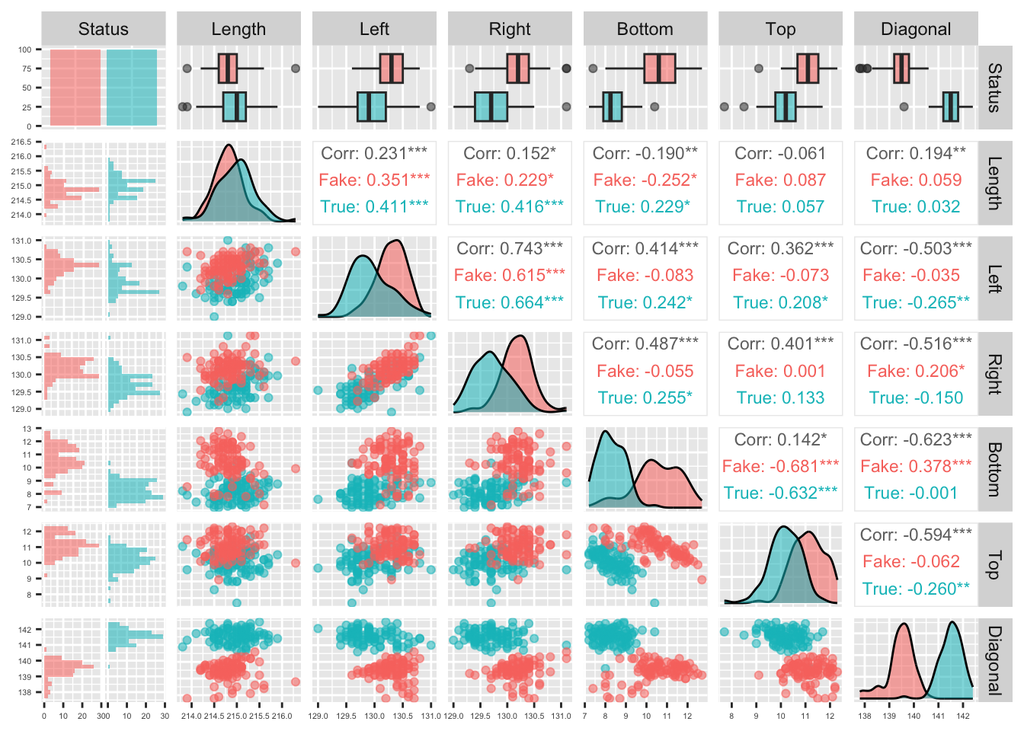

```r
ggpairs(banknote,
        aes(colour = c(rep("True", 100), rep("Fake", 100)),
            alpha = 0.5),
        upper = list(continuous = wrap("cor", size = 3)),
        lower = list(combo = wrap("facethist", bins = floor(1+3.322*log(dim(banknote)[1]))))) +
  theme(axis.text = element_text(size = 4))
```

```r
banknote$Status  <- as.numeric(banknote$Status)-1
```

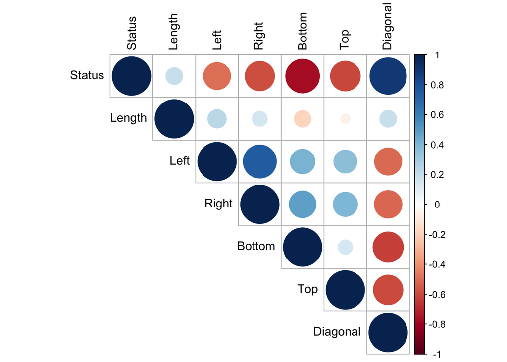

```r
corr_matrix <- cor(banknote)
corrplot(corr_matrix, method = "circle", type = "upper", tl.col = "black")
```

由 pairwise correlation matrix 可知 Bottom 和 Diagonal 的圓形相較於其它變數有明顯的差異；Bottom 為高度負相關、Diagonal 為高度正相關。

```r
kf <- kfcv(banknote, 20230327, 5)
```

# Naive Regression

## Full Model

```r
s1 <- 0
for(i in 1:5){
  d_test <- banknote[kf[[i]],]
  d_train <- banknote[-kf[[i]],]

  naivefit <- lm(Status ~ ., d_train)
  if(i==1){
    print(summary(naivefit))
  }
  p1 <- predict(naivefit, d_test, type = "response")
  print(table(round(p1), d_test$Status))
  s1 <- s1+sum(table(round(p1), d_test$Status)[c(1,4)])
}
```

```
##
## Call:
## lm(formula = Status ~ ., data = d_train)
##
## Residuals:
##      Min       1Q   Median       3Q      Max
## -0.38216 -0.08544 -0.00931  0.07123  0.56850
##
## Coefficients:
##              Estimate Std. Error t value Pr(>|t|)
## (Intercept) -20.11522    7.87926  -2.553   0.0117 *
## Length       -0.02331    0.03443  -0.677   0.4995
## Left          0.10545    0.05031   2.096   0.0377 *
## Right        -0.09951    0.04495  -2.214   0.0283 *
## Bottom       -0.15166    0.01194 -12.700  < 2e-16 ***
## Top          -0.16688    0.01901  -8.778 3.09e-15 ***
## Diagonal      0.19960    0.01747  11.423  < 2e-16 ***
## ---
## Signif. codes:  0 '***' 0.001 '**' 0.01 '*' 0.05 '.' 0.1 ' ' 1
##
## Residual standard error: 0.143 on 153 degrees of freedom
## Multiple R-squared:  0.9218, Adjusted R-squared:  0.9187
## F-statistic: 300.5 on 6 and 153 DF,  p-value: < 2.2e-16
##
##
##      0  1
##   0 22  0
##   1  0 18
##
##      0  1
##   0 22  0
##   1  0 18
##
##      0  1
##   0 18  0
##   1  0 22
##
##      0  1
##   0 15  1
##   1  0 24
##
##      0  1
##   0 23  0
##   1  0 17
```

```r
print(paste0(s1/2, "%"))
```

```
## [1] "99.5%"
```

1. **Bottom、Top、Diagonal** 三個變數為顯著影響模型的重要變數。
2. 即使在模型假設均為錯誤下，**Naive Regression** 準確值仍然非常高（**99.5%**），缺少的 0.5% 是因為有一個數據點沒有擬合到（pair 圖的 Status-Diagonal 的離群值）。
3. **K-fold cross validation** 可以使模型避免 **over fitting** 的問題。

## Model Selection

```r
s2 <- 0
for(i in 1:5){
  d_test <- banknote[kf[[i]],]
  d_train <- banknote[-kf[[i]],]

  naivefit_s <- fselect(d_train$Status, d_train[,2:7])
  if(i==1){
    print(summary(naivefit_s))
  }
  p2 <- predict(naivefit_s, d_test, type = "response")
  print(table(round(p2), d_test$Status))
  s2 <- s2+sum(table(round(p2), d_test$Status)[c(1,4)])
}
```

```
##
## Call:
## lm(formula = y ~ ., data = df_in)
##
## Residuals:
##      Min       1Q   Median       3Q      Max
## -0.37820 -0.08110 -0.01510  0.07726  0.54514
##
## Coefficients:
##              Estimate Std. Error t value Pr(>|t|)
## (Intercept) -23.61306    2.63315  -8.968 8.92e-16 ***
## Top          -0.17060    0.01856  -9.194 2.29e-16 ***
## Bottom       -0.15476    0.01133 -13.657  < 2e-16 ***
## Diagonal      0.19496    0.01729  11.276  < 2e-16 ***
## ---
## Signif. codes:  0 '***' 0.001 '**' 0.01 '*' 0.05 '.' 0.1 ' ' 1
##
## Residual standard error: 0.1445 on 156 degrees of freedom
## Multiple R-squared:  0.9185, Adjusted R-squared:  0.9169
## F-statistic: 586.1 on 3 and 156 DF,  p-value: < 2.2e-16
##
##
##      0  1
##   0 22  0
##   1  0 18
##
##      0  1
##   0 22  0
##   1  0 18
##
##      0  1
##   0 18  0
##   1  0 22
##
##      0  1
##   0 15  1
##   1  0 24
##
##      0  1
##   0 23  0
##   1  0 17
```

```r
print(paste0(s2/2, "%"))
```

```
## [1] "99.5%"
```

# Logistic Regression

## Full Model

```r
s3 <- 0
for(i in 1:5){
  d_test <- banknote[kf[[i]],]
  d_train <- banknote[-kf[[i]],]

  logitfit <- glm(Status ~ ., d_train, family = binomial)
  if(i==1){
    print(summary(logitfit))
  }
  p3 <- predict(logitfit, d_test, type = "response")
  print(table(round(p3), d_test$Status))
  s3 <- s3+sum(table(round(p3), d_test$Status)[c(1,4)])
}
```

```
##
## Call:
## glm(formula = Status ~ ., family = binomial, data = d_train)
##
## Deviance Residuals:
##        Min          1Q      Median          3Q         Max
## -4.822e-05  -2.100e-08   2.100e-08   2.100e-08   6.631e-05
##
## Coefficients:
##               Estimate Std. Error z value Pr(>|z|)
## (Intercept) -6.442e+03  2.935e+07   0.000    1.000
## Length       2.849e+00  1.037e+05   0.000    1.000
## Left        -3.821e+01  1.146e+05   0.000    1.000
## Right        4.735e+01  1.399e+05   0.000    1.000
## Bottom      -4.914e+01  3.108e+04  -0.002    0.999
## Top         -4.265e+01  6.153e+04  -0.001    0.999
## Diagonal     3.962e+01  2.480e+04   0.002    0.999
##
## (Dispersion parameter for binomial family taken to be 1)
##
##     Null deviance: 2.2171e+02  on 159  degrees of freedom
## Residual deviance: 1.2815e-08  on 153  degrees of freedom
## AIC: 14
##
## Number of Fisher Scoring iterations: 25
##
##
##      0  1
##   0 22  0
##   1  0 18
##
##      0  1
##   0 22  0
##   1  0 18
##
##      0  1
##   0 18  0
##   1  0 22
##
##      0  1
##   0 15  1
##   1  0 24
##
##      0  1
##   0 23  1
##   1  0 16
```

```r
print(paste0(s3/2, "%"))
```

```
## [1] "99%"
```

在放入全部變數的形況下 **Logistic Regression** 的結果**無法收斂**，推測為變數之間的共線性所導致。

## Model Selection

```r
s3 <- 0
for(i in 1:5){
  d_test <- banknote[kf[[i]],]
  d_train <- banknote[-kf[[i]],]

  logitfit <- glm(Status ~ ., d_train[c(1,6,7)], family = binomial)
  if(i==1){
    print(summary(logitfit))
  }
  p3 <- predict(logitfit, d_test, type = "response")
  print(table(round(p3), d_test$Status))
  s3 <- s3+sum(table(round(p3), d_test$Status)[c(1,4)])
}
```

```
##
## Call:
## glm(formula = Status ~ ., family = binomial, data = d_train[c(1,
##     6, 7)])
##
## Deviance Residuals:
##     Min       1Q   Median       3Q      Max
## -0.7872  -0.0629   0.0010   0.0292   3.4297
##
## Coefficients:
##             Estimate Std. Error z value Pr(>|z|)
## (Intercept) -811.852    207.937  -3.904 9.45e-05 ***
## Top           -2.314      1.343  -1.724   0.0848 .
## Diagonal       5.959      1.504   3.962 7.42e-05 ***
## ---
## Signif. codes:  0 '***' 0.001 '**' 0.01 '*' 0.05 '.' 0.1 ' ' 1
##
## (Dispersion parameter for binomial family taken to be 1)
##
##     Null deviance: 221.707  on 159  degrees of freedom
## Residual deviance:  16.479  on 157  degrees of freedom
## AIC: 22.479
##
## Number of Fisher Scoring iterations: 9
##
##
##      0  1
##   0 22  0
##   1  0 18
##
##      0  1
##   0 22  0
##   1  0 18
##
##      0  1
##   0 18  0
##   1  0 22
##
##      0  1
##   0 15  1
##   1  0 24
##
##      0  1
##   0 23  0
##   1  0 17
```

```r
print(paste0(s3/2, "%"))
```

```
## [1] "99.5%"
```

# Conclusion

1. Naive Regression 在執行上最為簡單，幾乎不須任何調整即可對資料做初步的分析。不過對不同的資料處理上有不同的效果，詳情可參考[Multinomial distribution data simulation](https://hans0803.github.io/myhtml.io/DR_and_ML_mndata.html)。
2. Logistic Regression 在變數的解釋性較佳，且在運算速度上也十分方便。不過在變數處理上可能會因**共線性或過度擬合**等問題導致模型**無法收斂**，在使用上需注意。
3. 不論是哪個模型均對變數的**離群值**相當敏感，離群值會使模型的預測能力受到影響，需輔以其他方法來處理問題

**References**

https://github.com/hans0803/APLM

https://www.investopedia.com/terms/v/variance-inflation-factor.asp

https://statisticsglobe.com/r-pairs-plot-example/

https://r-charts.com/correlation/ggpairs/

https://www.statisticshowto.com/choose-bin-sizes-statistics/

https://hans0803.github.io/myhtml.io/DR_and_ML_mndata.html